[figure not shown]

# **GA-NLP Mid-term Project: Support Ticket Categorization**

## **Business Context**

In today's dynamic business landscape, organizations are increasingly recognizing the pivotal role customer feedback plays in shaping the trajectory of their products and services. The ability to **swiftly and effectively respond to customer input** not only fosters enhanced customer experiences but also serves as a catalyst for growth, prolonged customer engagement, and the nurturing of lifetime value relationships.

As a dedicated Product Manager or Product Analyst, staying attuned to the voice of your customers is not just a best practice; it's a strategic imperative.

While your organization may be inundated with a wealth of customer-generated feedback and support tickets, your role entails much more than just processing these inputs. To make your efforts in managing customer experience and expectations truly impactful, you need a structured approach – a method that allows you to discern the most pressing issues, set priorities, and allocate resources judiciously.

One of the most effective strategies at your disposal as an organization is to harness the power of automated Support Ticket Categorization - **done in the modern day using Large Language Models and Generative AI.**

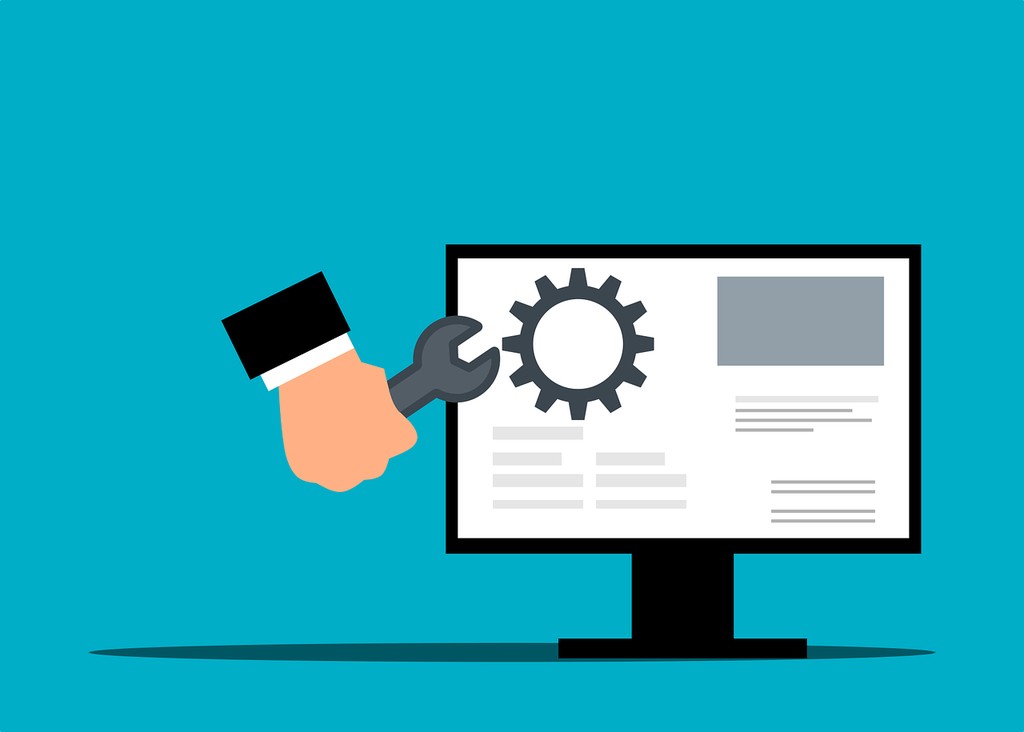

## **Project Objective**

Develop a Generative AI application using a Large Language Model to **automate the classification and processing of support tickets.** The application will aim to predict ticket categories, assign priority, suggest estimated resolution times, generate responses based on sentiment analysis, and store the results in a structured DataFrame.

## **Expected Output**

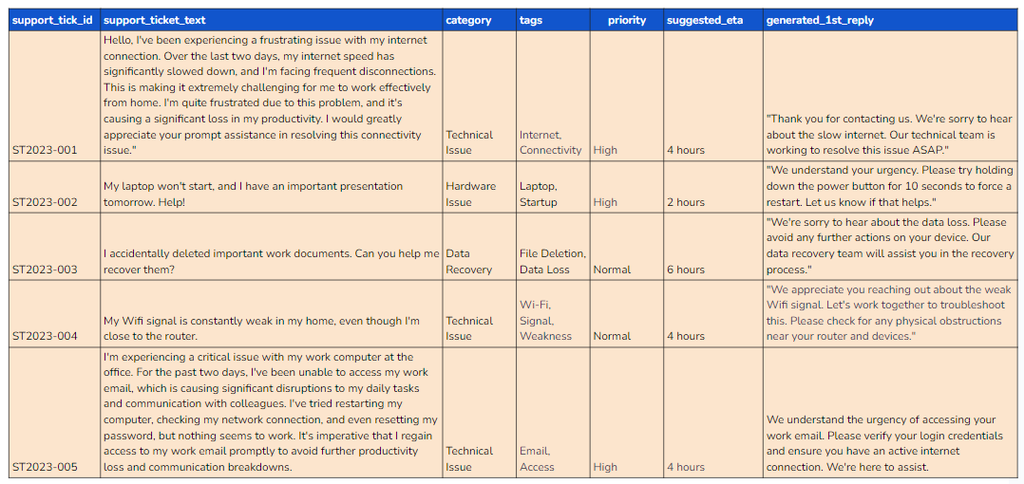

## **Model Loading**

```python
# Installation for GPU llama-cpp-python
!CMAKE_ARGS="-DLLAMA_CUBLAS=on" FORCE_CMAKE=1 pip install llama-cpp-python --force-reinstall --upgrade --no-cache-dir --verbose
```

[output not shown]

[output cut: 156 more lines]

[output not shown]

```python
# Install the hugging face hub
!pip install huggingface_hub -q
```

### **Q1: Write Python code that imports the 'hf_hub_download' function from the 'huggingface_hub' library and also imports the 'Llama' class from the 'llama_cpp' library.**

### **Ensure that the code is correctly formatted and ready for execution.** **(5 Marks)**

```python
# Import the 'hf_hub_download' function from the 'huggingface_hub' library
from huggingface_hub import hf_hub_download

# Import the 'Llama' class from the 'llama_cpp' library
from llama_cpp import Llama
```

### **Utilize the Mistral model**

```python
# Define the model name or path as a string (You can find this info from hugging face website) Use Mistral
model_name_or_path = "TheBloke/Mistral-7B-Instruct-v0.2-GGUF"

# Define the model basename as a string, indicating it's in the gguf format
model_basename = "mistral-7b-instruct-v0.2.Q6_K.gguf" # the model is in gguf format
```

```python
# Download the model from the Hugging Face Hub using the 'hf_hub_download' function
# by specifying the 'repo_id' and 'filename'
model_path = hf_hub_download(
    repo_id=model_name_or_path,
    filename=model_basename
)
```

```python
# Create an instance of the 'Llama' class with specified parameters
# remove the blank spaces and complete the code

lcpp_llm = Llama(
        model_path=model_path,
        n_threads=2,  # CPU cores
        n_batch=1024,  # Should be between 1 and n_ctx, consider the amount of VRAM in your GPU.
        n_gpu_layers=60,  # Change this value based on your model and your GPU VRAM pool.
        n_ctx=8192,  # Context window
    )
```

[output not shown]

[output cut: 48 more lines]

[output not shown]

### **Q2: Define the Prompt Template, System Message, generate_prompt** **(5 Marks)**

Define a **system message** as a string and assign it to the variable system_message.

Create a **zero shot prompt template** that incorporates the system message and user input.

Define **generate_prompt** function that takes both the system_message and user_input as arguments and formats them into a prompt template

Write a Python function called **generate_mistral_response** that takes a single parameter, support_ticket_text, which represents the user's support ticket text. Inside the function, you should perform the following tasks:

- **Combine the system_message and support_ticket_text to create a prompt string using generate_prompt function.**

*Generate a response from the Mistral model using the lcpp_llm instance with the following parameters:*

- prompt should be the combined prompt string.
- max_tokens should be set to 1200.
- temperature should be set to 0.
- top_p should be set to 0.95.
- repeat_penalty should be set to 1.2.
- top_k should be set to 50.
- stop should be set as a list containing '/s'.
- echo should be set to False. Extract and return the response text from the generated response.

Don't forget to provide a value for the system_message variable before using it in the function.

*What content and instructions should be included in the system message to guide the technical assistant when processing support tickets? Please provide a detailed description of the information and guidelines that the system message should contain.*

Create a prompt based on given instructions:

**Introduction:** Begin with an introduction stating your role and the task at hand. For example, "As a technical assistant specializing in customer input analysis, your goal is to extract specific information from customer support tickets."

**Step-by-Step Guide:** Provide a clear step-by-step guide for achieving the task. In this case, the steps are:

Classify Support Ticket Category

Create Tags

Assign Priority

Suggest ETA

Generate 1st Reply (Sentiment-Based)

**Instructions:**Outline each step briefly, focusing on the actions to be taken without delving into reasoning or specific implementation details. For instance:

**Classify Support Ticket Category:** Identify whether the support ticket falls under 'Technical issues', 'Hardware issues', or 'Data recovery' category based on the provided Support Ticket Text."

**Create Tags:** Generate tags to assist in classifying the ticket."

**Assign Priority:** Determine priority as 'High' or 'Normal' based on the content of the text."

**Suggest ETA:** Propose an estimated time of arrival for resolving the issue mentioned in the ticket text."

**Generate 1st Reply (Sentiment-Based):** Craft a polite response based on the sentiment expressed in the ticket."

**Output Format:** Specify the desired output format, which in this case is a JSON file containing keys: category, tag, priority, eta, and response.

```python
system_message= """You are an award winning customer service representative. Your task is to  classify and process support tickets.
You will be given support ticket text, and you will generate the following five outputs in respect to the support ticket:
1. Category: classify the ticket into one of the following three categories: Technical Issue, Hardware Issue, Data Recovery
2. Tags: generate tags that will help classifying the ticket properly. The Tags should be related to technical support issues
3. Priority: use your best judgement to evaluate how serious the issue in the support ticket is and assign either High or Normal value for Priority
4. Suggest ETA: Propose timeline for resolving the issue. Use your best judgement about how soon the issue should be resolved.
Do not exceed 4 hours for any High priority tickets. Do not give any other reasoning or explanations, only the proposed timeline.
5. Generated 1st Reply: write a short reply to the customer based on the sentiment expressed in the ticket. Be polite, you do not need to appologise.
Ensure the customer the issue is going to be reviewed and resolved. If there is anything there are any inouts or next steps the customer should take
for the resolution, advise to do so. Do not exceed 180 words

Do not provide any other information or explanations.

Please generate a JSON object with the following keys: 'category', 'tags', 'priority', 'eta', and 'reply'.
Here is the format I would like:

{
  "category": "<some category>",
  "tags": ["<technical tag1>", "<technical tag2>", "<technical tag3>"],
  "priority": "<priority level>",
  "eta": "<estimated time of arrival>",
  "reply": "<reply message>"
}

Please generate an example JSON object following this format.

"""
```

````python
zero_shot_prompt_template= """<s>[INST]{system_message}```{user_message}```[/INST]</s> """
````

```python
# Define function that combines user_prompt and system_message to create the prompt
def generate_prompt(system_message,user_input):
    prompt = zero_shot_prompt_template.format(system_message=system_message,user_message=user_input)
    return prompt
```

```python
def generate_mistral_response(support_ticket_text):

    # Combine user_prompt and system_message to create the prompt
    prompt = generate_prompt(system_message, support_ticket_text)

    # Generate a response from the LLaMA model

    try:
        response = lcpp_llm(
            prompt=prompt,
            max_tokens=200,
            temperature=0,
            top_p=0.95,
            repeat_penalty=1.2,
            echo=False # do not return the prompt
        )

    except Exception as e:
        print(e) # Log error and continue


    # Extract and return the response text
    response_text = response["choices"][0]['text']  ### Fill in the blank
    return response_text
```

### **Q3: Loading our Dataset (2 Marks)**

```python
# Import the pandas library and alias it as 'pd'
import pandas as pd

# Read a CSV file into a DataFrame and store it in the 'data' variable
data_zero_shot = pd.read_csv('/content/Support_ticket_text_data_mid_term.csv')
```

```python
data_zero_shot.head()
```

|  | support_tick_id | support_ticket_text |
| --- | --- | --- |
| 0 | ST2023-006 | My internet connection has significantly slowe... |
| 1 | ST2023-007 | Urgent help required! My laptop refuses to sta... |
| 2 | ST2023-008 | I've accidentally deleted essential work docum... |
| 3 | ST2023-009 | Despite being in close proximity to my Wi-Fi r... |
| 4 | ST2023-010 | My smartphone battery is draining rapidly, eve... |

```python
data_zero_shot.shape
```

```
(21, 2)
```

- After reading the CSV file into the 'data' DataFrame, how can you determine the shape of the DataFrame, and what information does 'data.shape' provide?
- What does 'data.head()' do, and how can it be used to inspect the contents of the DataFrame?

### **Q4: Create a new column in the DataFrame called 'mistral_response' and populate it with responses generated by applying the 'generate_mistral_response' function to each 'support_ticket_text' in the DataFrame ( 5Marks)**

```python
# Apply a function to each element in the 'support_ticket_text' column of the DataFrame 'data'
data_zero_shot['mistral_response_zero_shot'] = data_zero_shot['support_ticket_text'].apply(lambda x: generate_mistral_response(x))
```

[output not shown]

[output cut: 112 more lines]

[output not shown]

```python
## Check the new_column added
data_zero_shot.head()
```

|  | support_tick_id | support_ticket_text | mistral_response_zero_shot |
| --- | --- | --- | --- |
| 0 | ST2023-006 | My internet connection has significantly slowe... | {\n "category": "Technical Issue",\n "tags"... |
| 1 | ST2023-007 | Urgent help required! My laptop refuses to sta... | {\n "category": "Hardware Issue",\n "tags":... |
| 2 | ST2023-008 | I've accidentally deleted essential work docum... | {\n "category": "Data Recovery",\n "tags": ... |
| 3 | ST2023-009 | Despite being in close proximity to my Wi-Fi r... | {\n "category": "Technical Issue",\n "tags"... |
| 4 | ST2023-010 | My smartphone battery is draining rapidly, eve... | {\n "category": "Technical Issue",\n ... |

```python
data_zero_shot['mistral_response_zero_shot'][1]
```

```
' {\n  "category": "Hardware Issue",\n  "tags": ["Laptop Startup", "Power On"],\n  "priority": "High",\n  "eta": "Within 2 hours",\n  "reply": "Dear Valued Customer, We understand the urgency of your situation and apologize for any inconvenience caused. Our team will review your laptop issue as soon…
```

```python
# data_zero_shot['mistral_response_zero_shot'] = data_zero_shot['mistral_response_zero_shot'].applymap(lambda x: x.replace('\n', '') if isinstance(x, str) else x)
data_zero_shot['mistral_response_zero_shot'] = data_zero_shot['mistral_response_zero_shot'].str.replace('\n', '', regex=False)
data_zero_shot['mistral_response_zero_shot'] = data_zero_shot['mistral_response_zero_shot'].str.replace('\\', '', regex=False)
```

```python
data_zero_shot.head()
```

|  | support_tick_id | support_ticket_text | mistral_response_zero_shot |
| --- | --- | --- | --- |
| 0 | ST2023-006 | My internet connection has significantly slowe... | { "category": "Technical Issue", "tags": ["... |
| 1 | ST2023-007 | Urgent help required! My laptop refuses to sta... | { "category": "Hardware Issue", "tags": ["L... |
| 2 | ST2023-008 | I've accidentally deleted essential work docum... | { "category": "Data Recovery", "tags": ["Da... |
| 3 | ST2023-009 | Despite being in close proximity to my Wi-Fi r... | { "category": "Technical Issue", "tags": ["... |
| 4 | ST2023-010 | My smartphone battery is draining rapidly, eve... | { "category": "Technical Issue", "t... |

Make sure to validate each entry in the data['llama_response'] column thoroughly. If even one or two rows deviate from the JSON format (for instance, containing text preceding the JSON output), it could trigger an error when the extract_json_data function from question 5 is executed.

```python
data_zero_shot['mistral_response_zero_shot']
```

```
0      {  "category": "Technical Issue",  "tags": ["...
1      {  "category": "Hardware Issue",  "tags": ["L...
2      {  "category": "Data Recovery",  "tags": ["Da...
3      {  "category": "Technical Issue",  "tags": ["...
4      {      "category": "Technical Issue",      "t...
5      {      "category": "Data Recovery",      "tag...
6      {      "category": "Technical Issue",      "t...
7      {      "category": "Hardware Issue",      "ta...
8      {      "category": "Data Recovery",      "tag...
9      {  "category": "Hardware Issue",  "tags": ["G...
10     {      "category": "Data Recovery",      "tag...
11     {      "category": "Hardware Issue",      "ta...
12     {      "category": "Data Recovery",      "tag...
13     {      "category": "Data Recovery",      "tag...
14     {      "category": "Hardware Issue",      "ta...
15     {      "category": "Technical Issue",      "t...
16     {      "category": "Technical Issue",      "t...
17     {      "category": "Data Recovery",      "tag...
18     {      "category": "Data Recovery",      "tag...
19     {  "category": "Technical Issue",  "tags": ["...
20     {  "category": "Data Recovery",  "tags": ["So...
Name: mistral_response_zero_shot, dtype: object
```

### **Q5: Few Shot Prompting** **(5 Marks)**

Create few shot prompt using example given below

**user_input** = """My internet connection has significantly slowed down over the past two days, making it challenging to work efficiently from home. Frequent disconnections are causing major disruptions. Please assist in resolving this connectivity issue promptly."""

**assistant_output** ="""{"category": "Technical issues","tags": ["Internet connection", "Slow internet", "Disconnections"],"priority": "High","eta": "Within 4 hours","response": "Thank you for reaching out to us regarding your internet connectivity issues. We apologize for any inconvenience caused by the slow speeds and frequent disconnections. Our team is working diligently to address the matter as soon as possible"}"""

Define your **system_message**.

Define **first_turn_template** and **create few_shot_examples** using given user_input and assistant_output

Define **prediction template** to incorporate new_review

Define the **generate_prompt function** with **few_shot_examples** and **new_review** as variables.

````python
system_message= """You are an award winning customer service representative. Your task is to generate a JSON object for a presented support ticket as done in the examples below.
Presented support ticket will be delimited by triple backticks, that is, ```.
Do not provide any additional information or explanations. Do not exceed 180 words.
"""
````

```python
user_input1= '''My laptop won't start, and I have an important presentation tomorrow. Help!'''
```

```python
assistant_output1='''{"category": "Hardware Issue",  "tags": ["Laptop",  "Startup"],  "priority": "High",  "eta": "2 hours",  "reply": "We understand your urgency. Please try holding down the power button for 10 seconds to force a restart. Let us know if that helps."}'''
```

```python
user_input2='''I accidentally deleted important work documents. Can you help me recover them?'''
```

```python
assistant_output2='''{"category": "Data Recovery",  "tags": ["File Deletion",  "Data Loss"],  "priority": "Normal",  "eta": "6 hours",  "reply": "We're sorry to hear about the data loss. Please avoid any further actions on your device. Our data recovery team will assist you in the recovery process"}'''
```

```python
user_input3='''My Wifi signal is constantly weak in my home, even though I'm close to the router'''
```

```python
assistant_output3='''{"category": "Technical Issue",  "tags": ["Wi-Fi",  "Signal", "Weakness"],  "priority": "Normal",  "eta": "4 hours",  "reply": "We appreciate you reaching out about the weak Wifi signal. Let's work together to troubleshoot this. Please check for any physical obstructions near your router and devices"}'''
```

````python
first_turn_template = """<s>[INST]{system_message}```{user_message}```[/INST] {assistant_message}</s> """
examples_template =  """<s>[INST]```{user_message}```[/INST] {assistant_message}</s> """
prediction_template = """<s>[INST]\n ```{user_message}```[/INST]"""
````

```python
first_turn_example = first_turn_template.format(system_message = system_message,user_message=user_input1,assistant_message=assistant_output1)
examples1 = examples_template.format(user_message = user_input2, assistant_message = assistant_output2)
examples2 = examples_template.format(user_message = user_input3, assistant_message = assistant_output3)
```

```python
first_turn_example
```

````
'<s>[INST]You are an award winning customer service representative. Your task is to generate a JSON object for a presented support ticket as done in the examples below. \nPresented support ticket will be delimited by triple backticks, that is, ```.\nDo not provide any additional information or expla…
````

```python
few_shot_examples = first_turn_example + examples1 + examples2
```

```python
few_shot_examples
```

````
'<s>[INST]You are an award winning customer service representative. Your task is to generate a JSON object for a presented support ticket as done in the examples below. \nPresented support ticket will be delimited by triple backticks, that is, ```.\nDo not provide any additional information or expla…
````

```python
def prompt_generation(few_shot_examples,user_input):
  prompt= few_shot_examples + prediction_template.format(user_message = user_input)
  return prompt
```

```python
def generate_mistral_response(support_ticket_text):

    # Combine user_prompt and system_message to create the prompt
    prompt = prompt_generation(few_shot_examples, support_ticket_text)

    # Generate a response from the LLaMA model
    response = lcpp_llm(
            prompt=prompt,
            max_tokens=128,
            temperature=0,
            top_p=0.95,
            repeat_penalty=1.2,
            echo=False # do not return the prompt
    )

    # Extract and return the response text
    response_text = response["choices"][0]['text']  ### Fill in the blank
    return response_text
```

```python
# Import the pandas library and alias it as 'pd'
import pandas as pd

# Read a CSV file into a DataFrame and store it in the 'data' variable
data_few_shot = pd.read_csv('/content/Support_ticket_text_data_mid_term.csv')
```

```python
data_few_shot.head()
```

|  | support_tick_id | support_ticket_text |
| --- | --- | --- |
| 0 | ST2023-006 | My internet connection has significantly slowe... |
| 1 | ST2023-007 | Urgent help required! My laptop refuses to sta... |
| 2 | ST2023-008 | I've accidentally deleted essential work docum... |
| 3 | ST2023-009 | Despite being in close proximity to my Wi-Fi r... |
| 4 | ST2023-010 | My smartphone battery is draining rapidly, eve... |

Apply the generate_llama_response function once more to the support_ticket_text column to regenerate the llama_response column.

```python
data_few_shot['mistral_response_few_shot'] = data_few_shot['support_ticket_text'].apply(lambda x: generate_mistral_response(x))
```

[output not shown]

[output cut: 113 more lines]

[output not shown]

```python
data_few_shot.head()
```

|  | support_tick_id | support_ticket_text | mistral_response_few_shot |
| --- | --- | --- | --- |
| 0 | ST2023-006 | My internet connection has significantly slowe... | {"category": "Technical Issue", "tags": ["In... |
| 1 | ST2023-007 | Urgent help required! My laptop refuses to sta... | {"category": "Hardware Issue", "tags": ["Lap... |
| 2 | ST2023-008 | I've accidentally deleted essential work docum... | {"category": "Data Recovery", "tags": ["File... |
| 3 | ST2023-009 | Despite being in close proximity to my Wi-Fi r... | {"category": "Technical Issue", "tags": ["Wi... |
| 4 | ST2023-010 | My smartphone battery is draining rapidly, eve... | {"category": "Technical Issue", "tags": ["Sm... |

```python
data_few_shot['mistral_response_few_shot'][20]
```

```
' {"category": "Software Issue",  "tags": ["Application Crashes", "Data Loss"],  "priority": "High",  "eta": "12 hours",  "reply": "Thank you for bringing this complex issue to our attention. We\'re here to help and understand the impact on your workflow. To begin, could you please provide some more…
```

```python
data_few_shot['mistral_response_few_shot'] = data_few_shot['mistral_response_few_shot'].str.replace('\n', '', regex=False)
data_few_shot['mistral_response_few_shot'] = data_few_shot['mistral_response_few_shot'].str.replace('\\', '', regex=False)
```

### **Q6: Prepare the dataset in the desired format** **(3 Marks)**

- Run the code specified in the cells

```python
import json
```

```python
# Function to parse JSON data and extract key-value pairs
import json

def extract_json_data(json_str):
    try:
        # Attempt to load the JSON string
        data_dict = json.loads(json_str)
        return data_dict
    except json.JSONDecodeError as e:
        if json_str.endswith('}') or json_str.endswith('},'):
            # JSON string already ends with a closing brace or a closing brace preceded by a comma
            # Nothing more to add, return empty dictionary
            return {}
        elif json_str.endswith('"'):
            # JSON string ends with a ", add a closing brace
            json_str += '}'
        elif json_str.endswith(','):
            # JSON string ends with a comma, add a closing brace
            json_str += '}'
        else:
            # JSON string doesn't end with a comma or a closing brace, add both
            json_str += ',}'
        try:
            # Attempt to load the JSON string again
            data_dict = json.loads(json_str)
            return data_dict
        except json.JSONDecodeError as e:
            print(f"Error parsing JSON: {e}")
            return {}

data_zero_shot['mistral_response_zero_shot_parsed'] = data_zero_shot['mistral_response_zero_shot'].apply(extract_json_data)
data_few_shot['mistral_response_few_shot_parsed'] = data_few_shot['mistral_response_few_shot'].apply(extract_json_data)
```

# Zero Shot Results

```python
data_zero_shot.head()
```

|  | support_tick_id | support_ticket_text | mistral_response_zero_shot | mistral_response_zero_shot_parsed |
| --- | --- | --- | --- | --- |
| 0 | ST2023-006 | My internet connection has significantly slowe... | { "category": "Technical Issue", "tags": ["... | {'category': 'Technical Issue', 'tags': ['Inte... |
| 1 | ST2023-007 | Urgent help required! My laptop refuses to sta... | { "category": "Hardware Issue", "tags": ["L... | {'category': 'Hardware Issue', 'tags': ['Lapto... |
| 2 | ST2023-008 | I've accidentally deleted essential work docum... | { "category": "Data Recovery", "tags": ["Da... | {'category': 'Data Recovery', 'tags': ['Data L... |
| 3 | ST2023-009 | Despite being in close proximity to my Wi-Fi r... | { "category": "Technical Issue", "tags": ["... | {'category': 'Technical Issue', 'tags': ['Wi-F... |
| 4 | ST2023-010 | My smartphone battery is draining rapidly, eve... | { "category": "Technical Issue", "t... | {'category': 'Technical Issue', 'tags': ['Batt... |

```python
data_zero_shot['mistral_response_zero_shot_parsed'][0]
```

```
{'category': 'Technical Issue',
 'tags': ['Internet Connection', 'Connectivity', 'Disruption'],
 'priority': 'High',
 'eta': 'Within 2 hours',
 'reply': "Dear Valued Customer,nWe're sorry to hear that you have been experiencing connectivity issues with your internet, causing disruptions in your work. Our team is currently reviewing this matter and will do our best to resolve the issue as soon as possible.nIn the meantime, please ensure all…
```

```python
df = pd.json_normalize(data_zero_shot['mistral_response_zero_shot_parsed'])
```

```python
df.head()
```

|  | category | tags | priority | eta | reply |
| --- | --- | --- | --- | --- | --- |
| 0 | Technical Issue | [Internet Connection, Connectivity, Disruption] | High | Within 2 hours | Dear Valued Customer,nWe're sorry to hear that... |
| 1 | Hardware Issue | [Laptop Startup, Power On] | High | Within 2 hours | Dear Valued Customer, We understand the urgenc... |
| 2 | Data Recovery | [Data Loss] | High | Within 24 hours | Dear Valued Customer,nWe understand the urgenc... |
| 3 | Technical Issue | [Wi-Fi, Signal Strength] | High | Within 2 hours | Dear Valued Customer,nWe're sorry to hear that... |
| 4 | Technical Issue | [Battery, Smartphone] | Normal | Within 2 business days | Hello [Customer Name], thank you for reaching ... |

```python
data_zero_shot = pd.concat([data_zero_shot, df], axis = 1)
data_zero_shot.head()
```

|  | support_tick_id | support_ticket_text | mistral_response_zero_shot | mistral_response_zero_shot_parsed | category | tags | priority | eta | reply |
| --- | --- | --- | --- | --- | --- | --- | --- | --- | --- |
| 0 | ST2023-006 | My internet connection has significantly slowe... | { "category": "Technical Issue", "tags": ["... | {'category': 'Technical Issue', 'tags': ['Inte... | Technical Issue | [Internet Connection, Connectivity, Disruption] | High | Within 2 hours | Dear Valued Customer,nWe're sorry to hear that... |
| 1 | ST2023-007 | Urgent help required! My laptop refuses to sta... | { "category": "Hardware Issue", "tags": ["L... | {'category': 'Hardware Issue', 'tags': ['Lapto... | Hardware Issue | [Laptop Startup, Power On] | High | Within 2 hours | Dear Valued Customer, We understand the urgenc... |
| 2 | ST2023-008 | I've accidentally deleted essential work docum... | { "category": "Data Recovery", "tags": ["Da... | {'category': 'Data Recovery', 'tags': ['Data L... | Data Recovery | [Data Loss] | High | Within 24 hours | Dear Valued Customer,nWe understand the urgenc... |
| 3 | ST2023-009 | Despite being in close proximity to my Wi-Fi r... | { "category": "Technical Issue", "tags": ["... | {'category': 'Technical Issue', 'tags': ['Wi-F... | Technical Issue | [Wi-Fi, Signal Strength] | High | Within 2 hours | Dear Valued Customer,nWe're sorry to hear that... |
| 4 | ST2023-010 | My smartphone battery is draining rapidly, eve... | { "category": "Technical Issue", "t... | {'category': 'Technical Issue', 'tags': ['Batt... | Technical Issue | [Battery, Smartphone] | Normal | Within 2 business days | Hello [Customer Name], thank you for reaching ... |

```python
# Drop specific columns which are not needed from the DataFrame 'data'

columns_to_drop = ['mistral_response_zero_shot', 'mistral_response_zero_shot_parsed']
data_zero_shot = data_zero_shot.drop(columns = columns_to_drop)
```

```python
data_zero_shot
```

|  | support_tick_id | support_ticket_text | category | tags | priority | eta | reply |
| --- | --- | --- | --- | --- | --- | --- | --- |
| 0 | ST2023-006 | My internet connection has significantly slowe... | Technical Issue | [Internet Connection, Connectivity, Disruption] | High | Within 2 hours | Dear Valued Customer,nWe're sorry to hear that... |
| 1 | ST2023-007 | Urgent help required! My laptop refuses to sta... | Hardware Issue | [Laptop Startup, Power On] | High | Within 2 hours | Dear Valued Customer, We understand the urgenc... |
| 2 | ST2023-008 | I've accidentally deleted essential work docum... | Data Recovery | [Data Loss] | High | Within 24 hours | Dear Valued Customer,nWe understand the urgenc... |
| 3 | ST2023-009 | Despite being in close proximity to my Wi-Fi r... | Technical Issue | [Wi-Fi, Signal Strength] | High | Within 2 hours | Dear Valued Customer,nWe're sorry to hear that... |
| 4 | ST2023-010 | My smartphone battery is draining rapidly, eve... | Technical Issue | [Battery, Smartphone] | Normal | Within 2 business days | Hello [Customer Name], thank you for reaching ... |
| 5 | ST2023-011 | I'm locked out of my online banking account an... | Data Recovery | [Account Access, Password Reset] | High | Within 2 hours | Dear Valued Customer,nWe understand the urgenc... |
| 6 | ST2023-012 | My computer's performance is sluggish, severel... | Technical Issue | [Performance, Computer, Optimization] | High | Within 2 hours | Hello, we're sorry to hear that your computer ... |
| 7 | ST2023-013 | I'm experiencing a recurring blue screen error... | Hardware Issue | [Blue Screen Error, PC Crash] | High | Within 2 hours | Dear Valued Customer,nWe're sorry to hear that... |
| 8 | ST2023-014 | My external hard drive isn't being recognized ... | Data Recovery | [External Hard Drive, Data Recovery] | High | Within 24 hours | Dear Valued Customer,nnWe're sorry to hear tha... |
| 9 | ST2023-015 | The graphics card in my gaming laptop seems to... | Hardware Issue | [Graphics Card, Performance Issues] | High | Within 2 hours | Hello [Customer], we're sorry to hear that you... |
| 10 | ST2023-016 | I accidentally formatted my USB drive with cri... | Data Recovery | [Data Loss, File Recovery] | High | Within 2 business days | Dear Valued Customer,nnWe're sorry to hear abo... |
| 11 | ST2023-017 | My computer's screen has gone black, and I can... | Hardware Issue | [Display issue] | High | Within 2 hours | Dear Valued Customer,nWe're sorry to hear that... |
| 12 | ST2023-018 | I accidentally spilled water on my laptop, and... | Data Recovery | [Water Damage, Laptop] | High | Within 2 business days for assessment, longer ... | Hello [Customer], I'm sorry to hear about the ... |
| 13 | ST2023-019 | My USB flash drive is physically damaged, and ... | Data Recovery | [USB, Damaged, Data Recovery] | High | Within 2 business days | Dear Valued Customer,nnWe're sorry to hear tha... |
| 14 | ST2023-020 | The touchpad on my laptop has stopped working,... | Hardware Issue | [touchpad, laptop] | High | Within 2 hours | Hello, we're sorry to hear that you're experie... |
| 15 | ST2023-021 | My internet connection is frequently dropping,... | Technical Issue | [Internet Connection, Network] | High | Within 2 hours | Dear Valued Customer,nWe're sorry to hear that... |
| 16 | ST2023-022 | Wi-Fi is inconsistent despite proximity to the... | Technical Issue | [Wi-Fi, Connectivity] | High | Within 2 hours | Hello, we're sorry to hear that you are experi... |
| 17 | ST2023-023 | I accidentally formatted my USB drive with cru... | Data Recovery | [Data Loss, File Recovery] | High | Within 24 hours | We're sorry to hear that you have accidentally... |
| 18 | ST2023-024 | My external hard drive isn't being recognized,... | Data Recovery | [External Hard Drive, Data Recovery] | High | Within 24 hours | Dear Valued Customer,nnWe're sorry to hear tha... |
| 19 | ST2023-025 | I am experiencing a critical problem with my i... | Technical Issue | [Internet Connection, Slow Speed, Disconnections] | High | Within 4 hours | Dear Valued Customer,nWe apologize for the inc... |
| 20 | ST2023-026 | I hope this message finds you well. I am writi... | Data Recovery | [Software Issue, Data Loss] | High | Within 2 hours | Dear Valued Customer, Thank you for bringing t... |

# Few Shot Results

```python
data_few_shot.head()
```

|  | support_tick_id | support_ticket_text | mistral_response_few_shot | mistral_response_few_shot_parsed |
| --- | --- | --- | --- | --- |
| 0 | ST2023-006 | My internet connection has significantly slowe... | {"category": "Technical Issue", "tags": ["In... | {'category': 'Technical Issue', 'tags': ['Inte... |
| 1 | ST2023-007 | Urgent help required! My laptop refuses to sta... | {"category": "Hardware Issue", "tags": ["Lap... | {'category': 'Hardware Issue', 'tags': ['Lapto... |
| 2 | ST2023-008 | I've accidentally deleted essential work docum... | {"category": "Data Recovery", "tags": ["File... | {'category': 'Data Recovery', 'tags': ['File D... |
| 3 | ST2023-009 | Despite being in close proximity to my Wi-Fi r... | {"category": "Technical Issue", "tags": ["Wi... | {'category': 'Technical Issue', 'tags': ['Wi-F... |
| 4 | ST2023-010 | My smartphone battery is draining rapidly, eve... | {"category": "Technical Issue", "tags": ["Sm... | {'category': 'Technical Issue', 'tags': ['Smar... |

```python
data_few_shot['mistral_response_few_shot_parsed']
```

```
0     {'category': 'Technical Issue', 'tags': ['Inte...
1     {'category': 'Hardware Issue', 'tags': ['Lapto...
2     {'category': 'Data Recovery', 'tags': ['File D...
3     {'category': 'Technical Issue', 'tags': ['Wi-F...
4     {'category': 'Technical Issue', 'tags': ['Smar...
5     {'category': 'Security', 'tags': ['Account Acc...
6     {'category': 'Technical Issue', 'tags': ['Perf...
7     {'category': 'Hardware Issue', 'tags': ['Blue ...
8     {'category': 'Data Recovery', 'tags': ['Extern...
9     {'category': 'Hardware Issue', 'tags': ['Graph...
10    {'category': 'Data Recovery', 'tags': ['USB Dr...
11    {'category': 'Hardware Issue', 'tags': ['Scree...
12    {'category': 'Hardware Issue', 'tags': ['Lapto...
13    {'category': 'Data Recovery', 'tags': ['USB Fl...
14    {'category': 'Hardware Issue', 'tags': ['Touch...
15    {'category': 'Technical Issue', 'tags': ['Inte...
16    {'category': 'Technical Issue', 'tags': ['Wi-F...
17    {'category': 'Data Recovery', 'tags': ['USB Dr...
18    {'category': 'Data Recovery', 'tags': ['Extern...
19    {'category': 'Technical Issue', 'tags': ['Inte...
20    {'category': 'Software Issue', 'tags': ['Appli...
Name: mistral_response_few_shot_parsed, dtype: object
```

```python
data_few_shot['mistral_response_few_shot_parsed'][20]
```

```
{'category': 'Software Issue',
 'tags': ['Application Crashes', 'Data Loss'],
 'priority': 'High',
 'eta': '12 hours',
 'reply': "Thank you for bringing this complex issue to our attention. We're here to help and understand the impact on your workflow. To begin, could you please provide some more details about the affected applications, their versions, and any error messages or patterns you have observed? Additional…
```

```python
data_few_shot_concat = pd.concat([data_few_shot, pd.json_normalize(data_few_shot['mistral_response_few_shot_parsed'])], axis=1)
data_few_shot_concat.head()
```

|  | support_tick_id | support_ticket_text | mistral_response_few_shot | mistral_response_few_shot_parsed | category | tags | priority | eta | reply |
| --- | --- | --- | --- | --- | --- | --- | --- | --- | --- |
| 0 | ST2023-006 | My internet connection has significantly slowe... | {"category": "Technical Issue", "tags": ["In... | {'category': 'Technical Issue', 'tags': ['Inte... | Technical Issue | [Internet Connection, Slow Speed, Disconnection] | High | 2 hours | We understand the impact of your slow and disc... |
| 1 | ST2023-007 | Urgent help required! My laptop refuses to sta... | {"category": "Hardware Issue", "tags": ["Lap... | {'category': 'Hardware Issue', 'tags': ['Lapto... | Hardware Issue | [Laptop, Startup] | High | 1 hour | We understand the urgency of your situation. W... |
| 2 | ST2023-008 | I've accidentally deleted essential work docum... | {"category": "Data Recovery", "tags": ["File... | {'category': 'Data Recovery', 'tags': ['File D... | Data Recovery | [File Deletion, Urgent Data Loss] | High | 2 hours | We understand your concern regarding the subst... |
| 3 | ST2023-009 | Despite being in close proximity to my Wi-Fi r... | {"category": "Technical Issue", "tags": ["Wi... | {'category': 'Technical Issue', 'tags': ['Wi-F... | Technical Issue | [Wi-Fi, Signal, Weakness] | Normal | 4 hours | Thank you for bringing this to our attention a... |
| 4 | ST2023-010 | My smartphone battery is draining rapidly, eve... | {"category": "Technical Issue", "tags": ["Sm... | {'category': 'Technical Issue', 'tags': ['Smar... | Technical Issue | [Smartphone, Battery Drain] | Normal | 8 hours | We're here to help you with your smartphone ba... |

```python
# Drop specific columns which are not needed from the DataFrame 'data'

columns_to_drop = ['mistral_response_few_shot', 'mistral_response_few_shot_parsed']
data_few_shot_concat = data_few_shot_concat.drop(columns = columns_to_drop)
data_few_shot_concat
```

|  | support_tick_id | support_ticket_text | category | tags | priority | eta | reply |
| --- | --- | --- | --- | --- | --- | --- | --- |
| 0 | ST2023-006 | My internet connection has significantly slowe... | Technical Issue | [Internet Connection, Slow Speed, Disconnection] | High | 2 hours | We understand the impact of your slow and disc... |
| 1 | ST2023-007 | Urgent help required! My laptop refuses to sta... | Hardware Issue | [Laptop, Startup] | High | 1 hour | We understand the urgency of your situation. W... |
| 2 | ST2023-008 | I've accidentally deleted essential work docum... | Data Recovery | [File Deletion, Urgent Data Loss] | High | 2 hours | We understand your concern regarding the subst... |
| 3 | ST2023-009 | Despite being in close proximity to my Wi-Fi r... | Technical Issue | [Wi-Fi, Signal, Weakness] | Normal | 4 hours | Thank you for bringing this to our attention a... |
| 4 | ST2023-010 | My smartphone battery is draining rapidly, eve... | Technical Issue | [Smartphone, Battery Drain] | Normal | 8 hours | We're here to help you with your smartphone ba... |
| 5 | ST2023-011 | I'm locked out of my online banking account an... | Security | [Account Access, Password Reset] | High | 1 hour | We take security seriously, but we understand ... |
| 6 | ST2023-012 | My computer's performance is sluggish, severel... | Technical Issue | [Performance, Computer] | High | 2 hours | We understand the importance of a smooth workf... |
| 7 | ST2023-013 | I'm experiencing a recurring blue screen error... | Hardware Issue | [Blue Screen of Death, Crashing] | High | 8 hours | We're sorry for the inconvenience caused by yo... |
| 8 | ST2023-014 | My external hard drive isn't being recognized ... | Data Recovery | [External Hard Drive, Not Recognized] | High | 8 hours | We understand the urgency of your situation an... |
| 9 | ST2023-015 | The graphics card in my gaming laptop seems to... | Hardware Issue | [Graphics Card, Gaming Performance] | High | 8 hours | We're sorry for the inconvenience. Let us help... |
| 10 | ST2023-016 | I accidentally formatted my USB drive with cri... | Data Recovery | [USB Drive, Formatting] | High | 8 hours | We're sorry for your loss. Formatted USB drive... |
| 11 | ST2023-017 | My computer's screen has gone black, and I can... | Hardware Issue | [Screen, Blackout] | High | 2 hours | We understand the urgency of your situation. P... |
| 12 | ST2023-018 | I accidentally spilled water on my laptop, and... | Hardware Issue | [Laptop, Water Damage] | High | 24 hours for assessment, longer for data recov... | We're sorry to hear about the water damage. Pl... |
| 13 | ST2023-019 | My USB flash drive is physically damaged, and ... | Data Recovery | [USB Flash Drive, Physical Damage] | High | 12 hours | We're sorry for the inconvenience caused by yo... |
| 14 | ST2023-020 | The touchpad on my laptop has stopped working,... | Hardware Issue | [Touchpad, Laptop] | Medium | 8 hours | We're sorry for the inconvenience. Let's try s... |
| 15 | ST2023-021 | My internet connection is frequently dropping,... | Technical Issue | [Internet Connection, Dropouts] | High | 2 hours | We understand the urgency of your situation an... |
| 16 | ST2023-022 | Wi-Fi is inconsistent despite proximity to the... | Technical Issue | [Wi-Fi, Signal, Inconsistency] | High | 2 hours | We understand the impact on your work due to i... |
| 17 | ST2023-023 | I accidentally formatted my USB drive with cru... | Data Recovery | [USB Drive, Formatting] | High | 8 hours | We're sorry to hear about the formatted USB dr... |
| 18 | ST2023-024 | My external hard drive isn't being recognized,... | Data Recovery | [External Hard Drive, Not Recognized] | High | 8 hours | We understand the urgency of your situation an... |
| 19 | ST2023-025 | I am experiencing a critical problem with my i... | Technical Issue | [Internet Connection, Slow Speed, Disconnections] | High | 2 hours | We understand the urgency of your situation an... |
| 20 | ST2023-026 | I hope this message finds you well. I am writi... | Software Issue | [Application Crashes, Data Loss] | High | 12 hours | Thank you for bringing this complex issue to o... |

```python
df_comp = pd.concat([data_few_shot_concat, data_zero_shot], axis = 1)
df_comp.to_csv('few_shot_zero_shot_comp', index= False)
```

```python
df_comp.head()
```

|  | support_tick_id | support_ticket_text | category | tags | priority | eta | reply | support_tick_id | support_ticket_text | category | tags | priority | eta | reply |
| --- | --- | --- | --- | --- | --- | --- | --- | --- | --- | --- | --- | --- | --- | --- |
| 0 | ST2023-006 | My internet connection has significantly slowe... | Technical Issue | [Internet Connection, Slow Speed, Disconnection] | High | 2 hours | We understand the impact of your slow and disc... | ST2023-006 | My internet connection has significantly slowe... | Technical Issue | [Internet Connection, Connectivity, Disruption] | High | Within 2 hours | Dear Valued Customer,nWe're sorry to hear that... |
| 1 | ST2023-007 | Urgent help required! My laptop refuses to sta... | Hardware Issue | [Laptop, Startup] | High | 1 hour | We understand the urgency of your situation. W... | ST2023-007 | Urgent help required! My laptop refuses to sta... | Hardware Issue | [Laptop Startup, Power On] | High | Within 2 hours | Dear Valued Customer, We understand the urgenc... |
| 2 | ST2023-008 | I've accidentally deleted essential work docum... | Data Recovery | [File Deletion, Urgent Data Loss] | High | 2 hours | We understand your concern regarding the subst... | ST2023-008 | I've accidentally deleted essential work docum... | Data Recovery | [Data Loss] | High | Within 24 hours | Dear Valued Customer,nWe understand the urgenc... |
| 3 | ST2023-009 | Despite being in close proximity to my Wi-Fi r... | Technical Issue | [Wi-Fi, Signal, Weakness] | Normal | 4 hours | Thank you for bringing this to our attention a... | ST2023-009 | Despite being in close proximity to my Wi-Fi r... | Technical Issue | [Wi-Fi, Signal Strength] | High | Within 2 hours | Dear Valued Customer,nWe're sorry to hear that... |
| 4 | ST2023-010 | My smartphone battery is draining rapidly, eve... | Technical Issue | [Smartphone, Battery Drain] | Normal | 8 hours | We're here to help you with your smartphone ba... | ST2023-010 | My smartphone battery is draining rapidly, eve... | Technical Issue | [Battery, Smartphone] | Normal | Within 2 business days | Hello [Customer Name], thank you for reaching ... |

### **Q7: Share your observations and insights from this exercise, and your recommendations for a business looking to adopt a solution such as this (5 Marks)**

I used mistral-7b-instruct-v0.2.Q6_K.gguf model with 8192 context window length.

**Recommendations for adoption:** Model is suitable to be adopted in production, however it is important to emphasise that it should only be used to support human activities, and human oversight is necessary. That been said, it is able to provide huge support and generate results that can be used to expedite the processing of technical issues.